# Vignette Title

# All on one map

We can join the frequency on the stations and get a geographic overview of transit frequency by stop, binning the frequency for easier readability.

[figure not shown]

```r
plot_data <- stops %>% select(onestop_id) %>%
  left_join(frequency_counts %>% rename(onestop_id=origin_onestop_id),by="onestop_id")

#breaks <- classInt::classIntervals(plot_data$count)
breaks <- c(0,1,3,6,12,20,30,40,60,120,360,Inf)
labels <- c("Fewer than 1/hour","hourly - every 20 minutes","every 20 minutes - every 10 minutes",
            "every 10 minutes - every 5 minutes",
            "every 5 minutes - every 3 minutes",
            "every 3 minutes - every 2 minutes",
            "every 2 minutes - every 1.5 minutes",
            "every 1.5 minutes - every minute",
            "every minute - 2 per minute",
            "2 per minute - 3 per minute",
            "more than 3 per minute")
process_plot_data<-function(data){
  data %>% mutate(d=cut(count,breaks=breaks, labels=labels)) %>%
    mutate(d=as.character(d)) %>%
    mutate(d=ifelse(is.na(d),"None",d)) %>%
    mutate(d=factor(d,levels=c("None",labels))) %>%
    mutate(size=ifelse(is.na(count),0,sqrt(count)))
}
plot_data <- plot_data %>% process_plot_data


color_map <- setNames(c("grey60",viridis::viridis(length(labels))),c("None",labels))

ggplot(vancouver) +
  geom_sf() +
  map_theme +
  geom_sf(data=transit_routes,color="darkgrey",size=0.2) +
  scale_color_manual(values=color_map) +
  geom_sf(data=plot_data,aes(color=d,size=size), alpha=0.8,show.legend = "point") +
  scale_size_continuous(range=c(0.3,2),guide = FALSE) +
  coord_sf(xlim=c(bbox$xmin,bbox$xmax),ylim=c(bbox$ymin,bbox$ymax)) +
  labs(title="Vancouver transit frequency per stop/station 9am-10am",
       color="Departures/minute",caption="MountainMath, Transitland")
```

# Compaing to evening service

To round up the example we want to compare this to transit departures midnight to 1am.

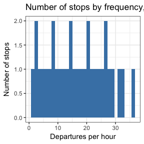

```r
params <- list(bbox=bbox,
               per_page=10000,
               origin_departure_between="24:00:00,25:00:00",
               date="2018-03-13")
schedule_stops_late <- simpleCache(get_transit_schedule_stops(params,get_all = TRUE),"yvr_schedule_24-45") %>%
  filter(origin_onestop_id %in% stops$onestop_id )

frequency_counts_late <- schedule_stops_late %>% group_by(origin_onestop_id) %>% summarize(count=n())

ggplot(frequency_counts_late %>% group_by(count) %>% summarize(n=n()), aes(x=count)) +
  geom_histogram(stat="bin",fill="steelblue") +
  theme_bw() +
  labs(title="Number of stops by frequency, midnight to 1am",y="Number of stops","Frequency of service per hour",x="Departures per hour")
```

As expected, the frequency is significantly lower at night, but still quite decent. We can again plot the geographic distribution.

[figure not shown]

```r
plot_data <- stops %>%
  select(onestop_id) %>%
  left_join(frequency_counts_late %>% rename(onestop_id=origin_onestop_id),by="onestop_id") %>%
  process_plot_data

ggplot(vancouver) +
  geom_sf() +
  map_theme +
  geom_sf(data=transit_routes,color="darkgrey",size=0.2) +
  scale_color_manual(values=color_map) +
  geom_sf(data=plot_data,aes(color=d,size=size), alpha=0.8,show.legend = "point") +
  coord_sf(xlim=c(bbox$xmin,bbox$xmax),ylim=c(bbox$ymin,bbox$ymax)) +
  scale_size_continuous(range=c(0.3,2),guide = FALSE) +
  labs(title="Vancouver transit frequency per stop/station midnight-1am",
       color="Departures/minute",caption="MountainMath, Transitland")
```